# Process the Raw Data and Metadata

```r
here::i_am("data/process_raw_data_metadata.qmd")

library(conflicted)
library(here)
library(readxl)
library(rnaturalearth)
library(rnaturalearthdata)
library(sf)
library(tidyverse)
conflicts_prefer(dplyr::filter, dplyr::lag)

data <- read_xlsx(
    here("data/raw/USFWS_Bat_Acoustic_Data/NightlyPassCounts.xlsx")
)
metadata <- read_csv(here("data/raw/Bat_Detector_Metadata/acoustic_sites.csv"))

theme_set(theme_bw())
```

The following objects contain information on state, province, and lake boundaries and will be used when making maps.

```r
usa <- ne_states(country = "United States of America", returnclass = "sf")
ontario <- ne_states(country = "Canada", returnclass = "sf") %>%
    filter(name == "Ontario")
great_lakes <- ne_download(
    scale = 50, type = "lakes", category = "physical", returnclass = "sf"
) %>%
    filter(
        name %in% c(
            "Lake Superior", "Lake Michigan", "Lake Huron", "Lake Erie",
            "Lake Ontario"
        )
    )
```

We’re interested in bat populations living near the Great Lakes. The map below reveals that a number of sites are far away from the Great Lakes. Those sites are in southern Minnesota, northern Iowa, central Indiana, southern Pennsylvania, and Texas.

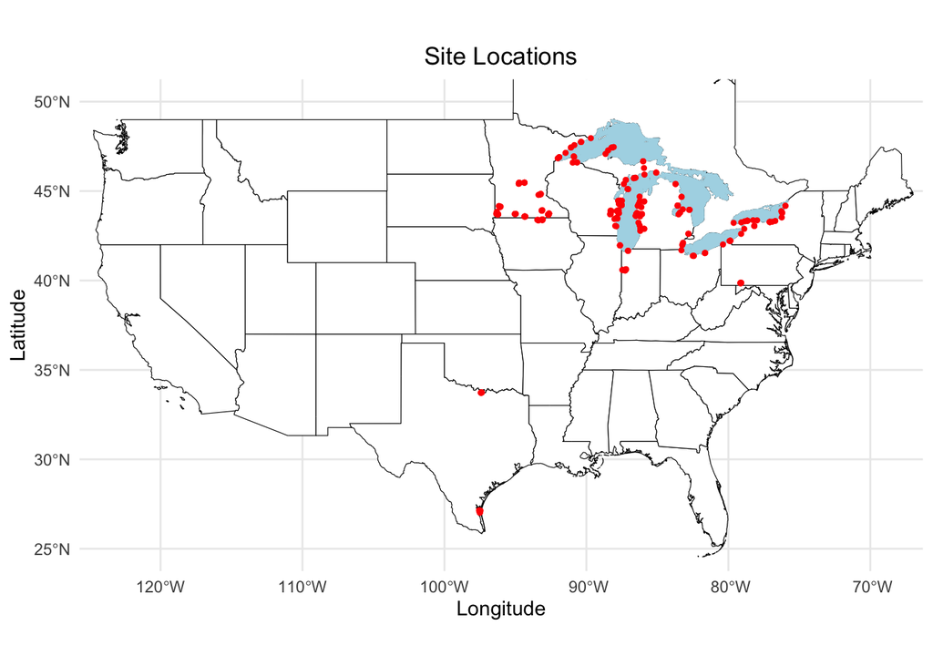

```r
ggplot() +
    geom_sf(data = usa, color = "black", fill = "white") +
    geom_sf(data = ontario, color = "black", fill = "white") +
    geom_sf(data = great_lakes, color = "lightblue", fill = "lightblue") +
    geom_point(aes(Long, Lat), metadata, color = "red", shape = "bullet") +
    coord_sf(xlim = c(-123, -69), ylim = c(25, 50)) +
    labs(x = "Longitude", y = "Latitude", title = "Site Locations") +
    theme_minimal() +
    theme(plot.title = element_text(hjust = 0.5))
```

We are going to identify the sites that are far away from the Great Lakes. It will help to have the state/province for each site; we find the sites’ states and provinces below.

```r
metadata_sf <- st_as_sf(
    select(metadata, c(AcousticSite, Long, Lat)),
    coords = c("Long", "Lat"),
    crs = 4326 # Need to use WGS84 CRS
)
site_states <- metadata_sf %>%
    st_join(rbind(usa, ontario)["name"]) %>%
    st_drop_geometry()
metadata <- metadata %>%
    inner_join(site_states, by = "AcousticSite") %>%
    relocate(state_province = name, .after = AcousticSite)
```

For a small fraction of the sites, no state or province was found.

```r
metadata %>%
    filter(is.na(state_province)) %>%
    select(AcousticSite:Lat) %>%
    print(n = Inf)
```

```
# A tibble: 22 × 4
   AcousticSite              state_province  Long   Lat
   <chr>                     <chr>          <dbl> <dbl>
 1 BAILEY                    <NA>           -87.1  45.1
 2 FOREST                    <NA>           -87.8  43.5
 3 GOOSE                     <NA>           -91.5  47.1
 4 HWKRDG                    <NA>           -92.0  46.8
 5 Kewaunee                  <NA>           -87.5  44.5
 6 LSSP                      <NA>           -87.9  43.0
 7 MUSK                      <NA>           -86.3  43.2
 8 NPS-GP                    <NA>           -89.7  48.0
 9 RadarF14_Batman-Manitou1  <NA>           -91.1  47.4
10 RadarF14_Batman-Manitou2  <NA>           -91.1  47.4
11 RadarF18_Robin-DetS2      <NA>           -83.2  42.0
12 RadarS15_Robin-Silica1    <NA>           -85.1  46.0
13 RadarS15_Robin-Silica2    <NA>           -85.1  46.0
14 RadarS17_Robin-Montrose1  <NA>           -87.6  42.0
15 RadarS17_Robin-Montrose2  <NA>           -87.6  42.0
16 RadarS17_Robin-Montrose3  <NA>           -87.6  42.0
17 RadarS18A_Robin-Trappist1 <NA>           -91.9  46.9
18 RadarS18A_Robin-Trappist2 <NA>           -91.9  46.9
19 SEUL-CHOIX                <NA>           -85.9  45.9
20 USFS-TFTE                 <NA>           -90.9  47.6
21 USG2                      <NA>           -83.6  44.2
22 WELLS                     <NA>           -87.4  45.4
```

All of these sites appear to be coastal sites.

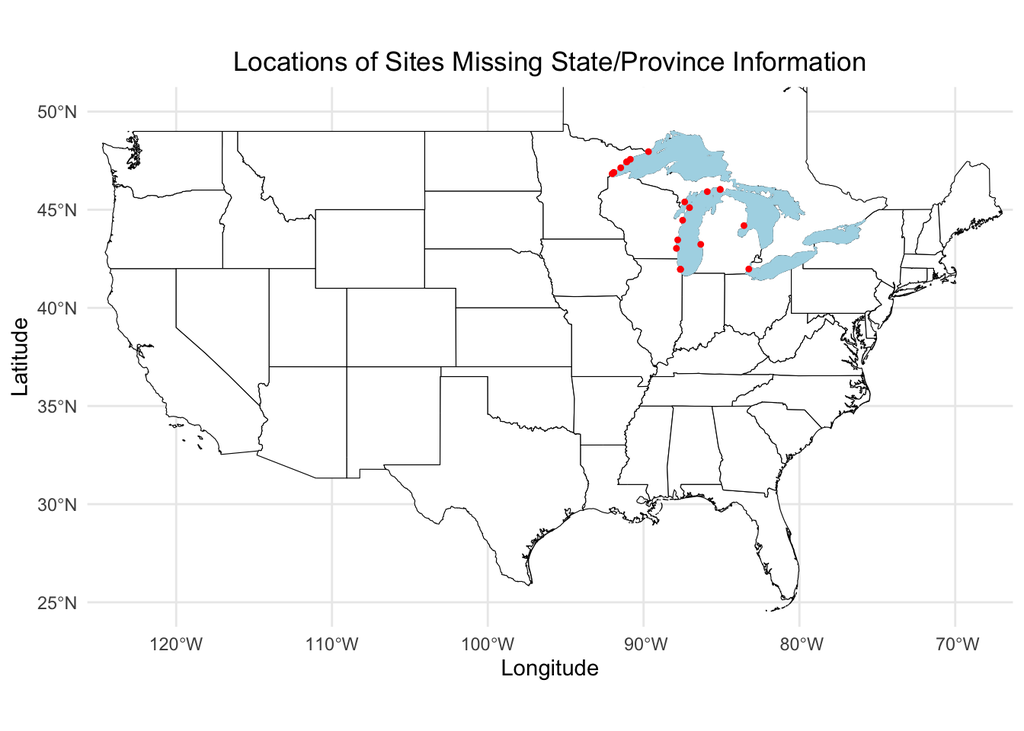

```r
ggplot() +
    geom_sf(data = usa, color = "black", fill = "white") +
    geom_sf(data = ontario, color = "black", fill = "white") +
    geom_sf(data = great_lakes, color = "lightblue", fill = "lightblue") +
    geom_point(
        aes(Long, Lat),
        filter(metadata, is.na(state_province)),
        color = "red", shape = "bullet"
    ) +
    coord_sf(xlim = c(-123, -69), ylim = c(25, 50)) +
    labs(
        x = "Longitude", y = "Latitude",
        title = "Locations of Sites Missing State/Province Information"
    ) +
    theme_minimal() +
    theme(plot.title = element_text(hjust = 0.5))
```

We use Google Maps to identify the states and provinces for those sites.

```r
metadata <- mutate(
    metadata,
    state_province = case_when(
        # https://www.google.com/maps/place/45°06'15.8%22N+87°03'10.1%22W
        AcousticSite == "BAILEY" ~ "Wisconsin",
        # https://www.google.com/maps/place/43°27'43.5%22N+87°48'38.8%22W
        AcousticSite == "FOREST" ~ "Wisconsin",
        # https://www.google.com/maps/place/47°08'15.9%22N+91°28'05.5%22W
        AcousticSite == "GOOSE" ~ "Minnesota",
        # https://www.google.com/maps/place/46°49'57.4%22N+92°01'08.3%22W
        AcousticSite == "HWKRDG" ~ "Minnesota",
        # https://www.google.com/maps/place/44°27'51.7%22N+87°29'42.2%22W
        AcousticSite == "Kewaunee" ~ "Wisconsin",
        # https://www.google.com/maps/place/43°01'52.7%22N+87°53'42.4%22W
        AcousticSite == "LSSP" ~ "Wisconsin",
        # https://www.google.com/maps/place/43°14'08.9%22N+86°19'57.4%22W
        AcousticSite == "MUSK" ~ "Michigan",
        # https://www.google.com/maps/place/47°57'31.8%22N+89°41'16.5%22W
        AcousticSite == "NPS-GP" ~ "Minnesota",
        # https://www.google.com/maps/place/47°26'11.7%22N+91°05'14.7%22W
        AcousticSite == "RadarF14_Batman-Manitou1" ~ "Minnesota",
        # https://www.google.com/maps/place/47°26'02.8%22N+91°05'16.0%22W
        AcousticSite == "RadarF14_Batman-Manitou2" ~ "Minnesota",
        # https://www.google.com/maps/place/41°58'47.2%22N+83°14'52.4%22W
        AcousticSite == "RadarF18_Robin-DetS2" ~ "Michigan",
        # https://www.google.com/maps/place/46°01'55.6%22N+85°04'59.0%22W
        AcousticSite == "RadarS15_Robin-Silica1" ~ "Michigan",
        # https://www.google.com/maps/place/46°02'00.9%22N+85°05'06.3%22W
        AcousticSite == "RadarS15_Robin-Silica2" ~ "Michigan",
        # https://www.google.com/maps/place/41°57'47.7%22N+87°38'24.5%22W
        AcousticSite == "RadarS17_Robin-Montrose1" ~ "Illinois",
        # https://www.google.com/maps/place/41°57'45.9%22N+87°37'59.2%22W
        AcousticSite == "RadarS17_Robin-Montrose2" ~ "Illinois",
        # https://www.google.com/maps/place/41°57'47.7%22N+87°37'53.4%22W
        AcousticSite == "RadarS17_Robin-Montrose3" ~ "Illinois",
        # https://www.google.com/maps/place/46°53'49.8%22N+91°54'47.4%22W
        AcousticSite == "RadarS18A_Robin-Trappist1" ~ "Minnesota",
        # https://www.google.com/maps/place/46°53'46.9%22N+91°54'46.8%22W
        AcousticSite == "RadarS18A_Robin-Trappist2" ~ "Minnesota",
        # https://www.google.com/maps/place/45°55'16.0%22N+85°54'42.8%22W
        AcousticSite == "SEUL-CHOIX" ~ "Michigan",
        # https://www.google.com/maps/place/47°34'11.0%22N+90°51'03.2%22W
        AcousticSite == "USFS-TFTE" ~ "Minnesota",
        # https://www.google.com/maps/place/44°11'25.7%22N+83°33'31.4%22W
        AcousticSite == "USG2" ~ "Michigan",
        # https://www.google.com/maps/place/45°23'48.5%22N+87°21'48.7%22W
        AcousticSite == "WELLS" ~ "Michigan",
        .default = state_province
    )
)
```

Below are the states with sites.

```r
count(metadata, state_province, sort = TRUE, name = "num_sites")
```

```
# A tibble: 11 × 2
   state_province num_sites
   <chr>              <int>
 1 Michigan              74
 2 Minnesota             73
 3 Wisconsin             45
 4 New York              25
 5 Indiana               15
 6 Pennsylvania          14
 7 Texas                 11
 8 Iowa                   7
 9 Ohio                   7
10 Illinois               3
11 Ontario                2
```

It looks like the sites far away from the Great Lakes are those that are either in Minnesota and below 46°N, or are in Iowa, or are below 41°N.

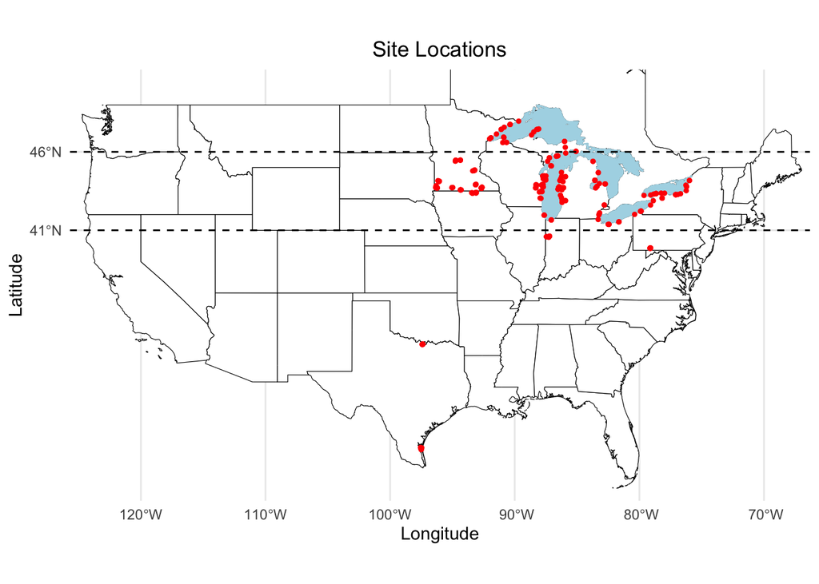

```r
ggplot() +
    geom_sf(data = usa, color = "black", fill = "white") +
    geom_sf(data = ontario, color = "black", fill = "white") +
    geom_sf(data = great_lakes, color = "lightblue", fill = "lightblue") +
    geom_point(aes(Long, Lat), metadata, color = "red", shape = "bullet") +
    geom_hline(yintercept = c(41, 46), linetype = "dashed") +
    scale_y_continuous(breaks = c(41, 46)) +
    coord_sf(xlim = c(-123, -69), ylim = c(25, 50)) +
    labs(x = "Longitude", y = "Latitude", title = "Site Locations") +
    theme_minimal() +
    theme(plot.title = element_text(hjust = 0.5))
```

We filter out the sites that are far away from the Great Lakes.

```r
great_lakes_metadata <- filter(
    metadata,
    !(
        ((state_province == "Minnesota") & (Lat <= 46)) |
            (state_province == "Iowa") |
            (Lat <= 41)
    )
)
```

The site map now looks like this.

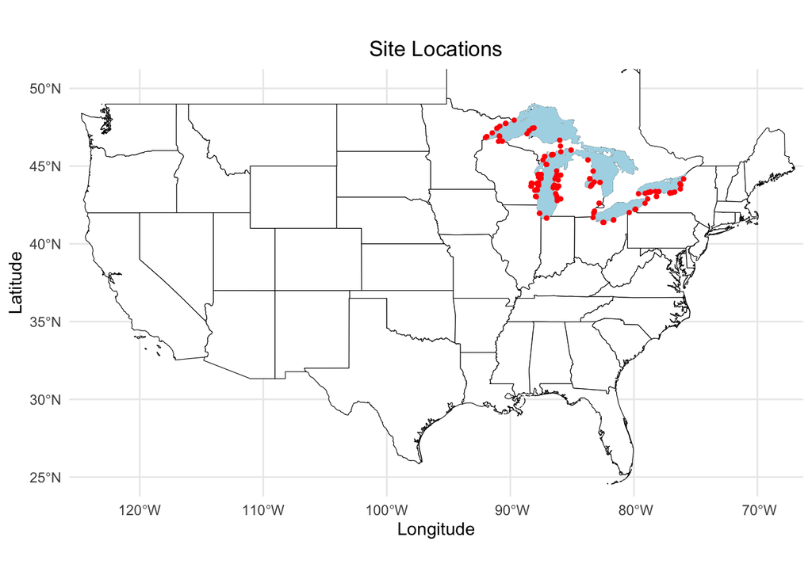

```r
ggplot() +
    geom_sf(data = usa, color = "black", fill = "white") +
    geom_sf(data = ontario, color = "black", fill = "white") +
    geom_sf(data = great_lakes, color = "lightblue", fill = "lightblue") +
    geom_point(
        aes(Long, Lat), great_lakes_metadata, color = "red", shape = "bullet"
    ) +
    coord_sf(xlim = c(-123, -69), ylim = c(25, 50)) +
    labs(x = "Longitude", y = "Latitude", title = "Site Locations") +
    theme_minimal() +
    theme(plot.title = element_text(hjust = 0.5))
```

We filter out the data for the sites that are far away from the Great Lakes.

```r
great_lakes_data <- filter(
    data, AcousticSite %in% great_lakes_metadata$AcousticSite
)
```

The percentage reductions in the number of sites and the number of data records are below.

```r
c(
    num_sites_reduc = 100 * (nrow(great_lakes_metadata) / nrow(metadata) - 1),
    num_data_recs_reduc = 100 * (nrow(great_lakes_data) / nrow(data) - 1)
)
```

```
    num_sites_reduc num_data_recs_reduc
          -36.23188           -43.11083
```

We save the data and metadata for the Great Lakes sites under shorter names.

```r
env <- list2env(list(metadata = great_lakes_metadata, data = great_lakes_data))
save(
    list = ls(env),
    file = here("data/processed/data_metadata.RData"),
    envir = env
)
```